# task1

2023-02-25

# Introduction

## Load packages

```r
library(dplyr)
library(sf)
library(leaflet)
library(lubridate)
```

```r
library(mapsf)
library(tidyr)
library(ggplot2)
```

## Load data and project spatial features

- Load data and project spatial features
  - `heetchmarchcropwithneib.Rds`: les données de heetch avec les quartiers associés
  - `casaneib.geojson`: les quartiers de casa
  - `casabound.geojson`: les bords de casa

```r
heetchPoints <-readRDS("../data/heetchmarchcropwithneib.Rds")
casaNeib <-st_read("../data/casaneib.geojson")
casaBound <- st_read("../data/casabound.geojson") #des poinrts qui forment une
casaNeibProj <-st_transform(casaNeib, crs=26191)
heetchPointsProj <-st_transform(heetchPoints, crs=26191)
casaBoundProj <-st_transform(casaBound, crs=26191)
rm(heetchPoints)
rm(casaNeib)
#heetch_points_proj
head(heetchPointsProj) #(driver_id, location_at_local_time, geometry)
```

```
## Simple feature collection with 6 features and 3 fields
## Attribute-geometry relationship: 2 constant, 0 aggregate, 0 identity, 1 NA's
## Geometry type: POINT
## Dimension:     XY
## Bounding box:  xmin: 289990.8 ymin: 329212.8 xmax: 294476.8 ymax: 335131.2
## Projected CRS: Merchich / Nord Maroc
## # A tibble: 6 x 4
##   driver_id                  location_at_local~1            geometry  NEIB
##   <chr>                      <dttm>                      <POINT [m]> <int>
## 1 54f25ae2-9f19-489e-8c6d-b~ 2019-03-01 00:03:57   (292984 334588.9)    24
## 2 e99f5a59-37ca-4b3f-882a-3~ 2019-03-01 00:29:25 (294288.8 334290.9)    24
## 3 cd443d0e-a574-4e17-90a5-3~ 2019-03-01 00:31:38 (290144.8 329212.8)    15
## 4 cbb30118-bfbc-4938-a61a-0~ 2019-03-01 00:48:01   (294249 333853.6)    24
## 5 d34e899b-1946-4143-ac0d-2~ 2019-03-01 01:17:19 (294476.8 333349.5)    24
## 6 255db2aa-d239-4126-902a-2~ 2019-03-01 02:10:42 (289990.8 335131.2)    10
## # ... with abbreviated variable name 1: location_at_local_time
```

```r
class(heetchPointsProj)
```

```
## [1] "sf"         "tbl_df"     "tbl"        "data.frame"
```

```r
str(heetchPointsProj)
```

```
## sf [4,637,824 x 4] (S3: sf/tbl_df/tbl/data.frame)
##  $ driver_id             : chr [1:4637824] "54f25ae2-9f19-489e-8c6d-ba8ede2f0ff0" "e99f5a59-37ca-4b3f-882a-3d87be82a830" "cd443d0e-a574-4e17-90a5-39e0ef4ba435" "cbb30118-bfbc-4938-a61a-001546aafd20" ...
##  $ location_at_local_time: POSIXct[1:4637824], format: "2019-03-01 00:03:57" "2019-03-01 00:29:25" ...
##  $ geometry              :sfc_POINT of length 4637824; first list element:  'XY' num [1:2] 292984 334589
##  $ NEIB                  : int [1:4637824] 24 24 15 24 24 10 24 10 24 10 ...
##  - attr(*, "sf_column")= chr "geometry"
##  - attr(*, "agr")= Factor w/ 3 levels "constant","aggregate",..: 1 1 NA
##   ..- attr(*, "names")= chr [1:3] "driver_id" "location_at_local_time" "NEIB"
```

```r
#heetch_points_proj
head(casaNeibProj) #(driver_id, location_at_local_time, geometry)
```

```
## Simple feature collection with 6 features and 2 fields
## Geometry type: MULTIPOLYGON
## Dimension:     XY
## Bounding box:  xmin: 282881.1 ymin: 324168 xmax: 309041.6 ymax: 340772.6
## Projected CRS: Merchich / Nord Maroc
##           GID_4       NAME_4                       geometry
## 1 MAR.5.1.1.1_1    Bouskoura MULTIPOLYGON (((292837.2 32...
## 2 MAR.5.1.1.2_1  Dar Bouazza MULTIPOLYGON (((282881.2 33...
## 3 MAR.5.1.2.2_1  Lahraouyine MULTIPOLYGON (((300476.7 32...
## 4 MAR.5.1.3.1_1  Ahl Laghlam MULTIPOLYGON (((304228.6 33...
## 5 MAR.5.1.4.1_1    Ain Chock MULTIPOLYGON (((297286 3272...
## 6 MAR.5.1.5.1_1 Ain Harrouda MULTIPOLYGON (((304132.4 33...
```

```r
class(casaNeibProj)
```

```
## [1] "sf"         "data.frame"
```

```r
str(casaNeibProj)
```

```
## Classes 'sf' and 'data.frame':   29 obs. of  3 variables:
##  $ GID_4   : chr  "MAR.5.1.1.1_1" "MAR.5.1.1.2_1" "MAR.5.1.2.2_1" "MAR.5.1.3.1_1" ...
##  $ NAME_4  : chr  "Bouskoura" "Dar Bouazza" "Lahraouyine" "Ahl Laghlam" ...
##  $ geometry:sfc_MULTIPOLYGON of length 29; first list element: List of 1
##   ..$ :List of 1
##   .. ..$ : num [1:20, 1:2] 292837 292881 293019 293189 293255 ...
##   ..- attr(*, "class")= chr [1:3] "XY" "MULTIPOLYGON" "sfg"
##  - attr(*, "sf_column")= chr "geometry"
##  - attr(*, "agr")= Factor w/ 3 levels "constant","aggregate",..: NA NA
##   ..- attr(*, "names")= chr [1:2] "GID_4" "NAME_4"
```

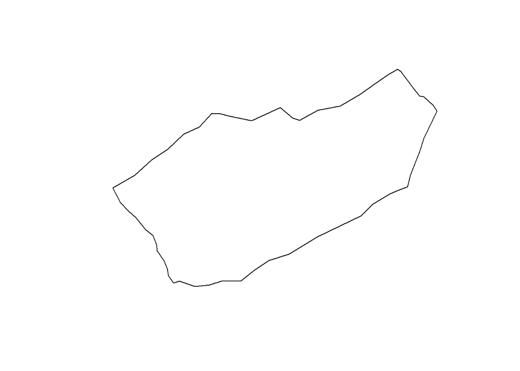

```r
plot(casaBound$geometry)#un plot de la géométrie
```

```r
class(casaBound)
```

```
## [1] "sf"         "data.frame"
```

```r
str(casaBound)
```

```
## Classes 'sf' and 'data.frame':   1 obs. of  2 variables:
##  $ id      : int 1
##  $ geometry:sfc_POLYGON of length 1; first list element: List of 1
##   ..$ : num [1:58, 1:2] -7.74 -7.72 -7.71 -7.69 -7.68 ...
##   ..- attr(*, "class")= chr [1:3] "XY" "POLYGON" "sfg"
##  - attr(*, "sf_column")= chr "geometry"
##  - attr(*, "agr")= Factor w/ 3 levels "constant","aggregate",..: NA
##   ..- attr(*, "names")= chr "id"
```

# Pour chaque heure, combien de drivers

## Créer la section du 1er Mars

Sectionner le fichier `heetchPointsProj` pour n’utiliser que les données de 1er mars

```r
heetchPointsProj$Day <-day(heetchPointsProj$location_at_local_time)
heetchPointsProj$Hour <-hour(heetchPointsProj$location_at_local_time)
heetchM1Proj <-heetchPointsProj %>%
  filter(Day==1)
head(heetchM1Proj) #(driver_id, location_at_local_time, geometry, NEIB, Day, Hour)
```

```
## Simple feature collection with 6 features and 5 fields
## Attribute-geometry relationship: 2 constant, 0 aggregate, 0 identity, 3 NA's
## Geometry type: POINT
## Dimension:     XY
## Bounding box:  xmin: 289990.8 ymin: 329212.8 xmax: 294476.8 ymax: 335131.2
## Projected CRS: Merchich / Nord Maroc
## # A tibble: 6 x 6
##   driver_id      location_at_local~1            geometry  NEIB   Day  Hour
##   <chr>          <dttm>                      <POINT [m]> <int> <int> <int>
## 1 54f25ae2-9f19~ 2019-03-01 00:03:57   (292984 334588.9)    24     1     0
## 2 e99f5a59-37ca~ 2019-03-01 00:29:25 (294288.8 334290.9)    24     1     0
## 3 cd443d0e-a574~ 2019-03-01 00:31:38 (290144.8 329212.8)    15     1     0
## 4 cbb30118-bfbc~ 2019-03-01 00:48:01   (294249 333853.6)    24     1     0
## 5 d34e899b-1946~ 2019-03-01 01:17:19 (294476.8 333349.5)    24     1     1
## 6 255db2aa-d239~ 2019-03-01 02:10:42 (289990.8 335131.2)    10     1     2
## # ... with abbreviated variable name 1: location_at_local_time
```

```r
str(heetchM1Proj)
```

```
## sf [166,259 x 6] (S3: sf/tbl_df/tbl/data.frame)
##  $ driver_id             : chr [1:166259] "54f25ae2-9f19-489e-8c6d-ba8ede2f0ff0" "e99f5a59-37ca-4b3f-882a-3d87be82a830" "cd443d0e-a574-4e17-90a5-39e0ef4ba435" "cbb30118-bfbc-4938-a61a-001546aafd20" ...
##  $ location_at_local_time: POSIXct[1:166259], format: "2019-03-01 00:03:57" "2019-03-01 00:29:25" ...
##  $ geometry              :sfc_POINT of length 166259; first list element:  'XY' num [1:2] 292984 334589
##  $ NEIB                  : int [1:166259] 24 24 15 24 24 10 24 10 24 10 ...
##  $ Day                   : int [1:166259] 1 1 1 1 1 1 1 1 1 1 ...
##  $ Hour                  : int [1:166259] 0 0 0 0 1 2 2 2 3 3 ...
##  - attr(*, "sf_column")= chr "geometry"
##  - attr(*, "agr")= Factor w/ 3 levels "constant","aggregate",..: 1 1 NA NA NA
##   ..- attr(*, "names")= chr [1:5] "driver_id" "location_at_local_time" "NEIB" "Day" ...
```

```r
nrow(heetchM1Proj) #166259
```

```
## [1] 166259
```

## Grouper par heure/ par identifiant chauffeur et par quartier

On compte le nombre de tuple (heure, quartier, driver)

```r
nestedPts <-heetchM1Proj %>%
  st_drop_geometry() %>%
  group_by(Hour, NEIB, driver_id) %>%
  summarize(NBPTS=n())
nrow(nestedPts) #5032
```

```
## [1] 17155
```

```r
head(nestedPts) #Hour,driver_id,NEIB,NBPTS
```

```
## # A tibble: 6 x 4
## # Groups:   Hour, NEIB [1]
##    Hour  NEIB driver_id                            NBPTS
##   <int> <int> <chr>                                <int>
## 1     0     2 00fe68d5-31a8-400d-bea7-795c991d9fb4    54
## 2     0     2 04bc41d2-6da6-4837-8eae-f7b84b09848b     1
## 3     0     2 074de5ce-3b19-46ba-8f88-512fc50a0911     3
## 4     0     2 0d69521b-5810-4dff-8434-97c6bd190d3f     1
## 5     0     2 0e45c226-3668-48f1-95a1-3aa4804ea1a2    10
## 6     0     2 21753979-e6f6-4a41-8b4e-3055fc889e6c    19
```

```r
class(nestedPts)
```

```
## [1] "grouped_df" "tbl_df"     "tbl"        "data.frame"
```

## Selectionner le quartier principal pour chaque chauffeur à chaque heure

Pour chaque tuple (driver, heure), on identifie le quartier où le driver est le plus représenté à cette heure là

```r
mainNeib <-nestedPts %>%
  group_by(driver_id, Hour) %>%
  arrange(desc(NBPTS)) %>%
  slice(1)
nrow(mainNeib) #1374
```

```
## [1] 4834
```

```r
class(mainNeib) #Hour,driver_id,NEIB,NBPTS
```

```
## [1] "grouped_df" "tbl_df"     "tbl"        "data.frame"
```

```r
head(mainNeib)
```

```
## # A tibble: 6 x 4
## # Groups:   driver_id, Hour [6]
##    Hour  NEIB driver_id                            NBPTS
##   <int> <int> <chr>                                <int>
## 1    20    11 000f83ec-cc21-460f-a2e4-5935356b5b92     4
## 2    22    14 000f83ec-cc21-460f-a2e4-5935356b5b92    13
## 3    23     2 000f83ec-cc21-460f-a2e4-5935356b5b92    34
## 4    20    10 00b204e1-9567-432f-836c-1d70e5547217     5
## 5    21    15 00b204e1-9567-432f-836c-1d70e5547217    15
## 6    22    24 00b204e1-9567-432f-836c-1d70e5547217    24
```

## Pour chaque heure, calculer le nombre de chauffeurs

```r
NbDriverPerHour <-nestedPts %>%
  group_by(Hour) %>%
  summarize(NBDRiver=n()) %>%
  arrange(desc(NBDRiver))
nrow(NbDriverPerHour) #8
```

```
## [1] 24
```

```r
class(NbDriverPerHour) #Hour,NBDRiver
```

```
## [1] "tbl_df"     "tbl"        "data.frame"
```

```r
head(NbDriverPerHour)
```

```
## # A tibble: 6 x 2
##    Hour NBDRiver
##   <int>    <int>
## 1    22     1495
## 2    21     1459
## 3    23     1261
## 4    20     1193
## 5     0      993
## 6     1      712
```

## Pour chaque heure, pour chaque quartier, calculer le nombre de chauffeurs

```r
mainNeibN <-nestedPts %>%
  group_by(Hour, NEIB) %>%
  summarize(NBDRiver=n()) %>%
  arrange(desc(NBDRiver))
nrow(mainNeibN) #198
```

```
## [1] 606
```

```r
class(mainNeibN) #Hour,NBDRiver,NEIB
```

```
## [1] "grouped_df" "tbl_df"     "tbl"        "data.frame"
```

```r
head(mainNeibN)
```

```
## # A tibble: 6 x 3
## # Groups:   Hour [3]
##    Hour  NEIB NBDRiver
##   <int> <int>    <int>
## 1    22    24      206
## 2    21    24      197
## 3    22    10      178
## 4    21    10      175
## 5    23    24      174
## 6    21    14      158
```

## Trouver les heures de pointes

- On filtre les drivers les tuple (heure, quartier) pour lequel on a plus de 30 drivers.
- Puis, on compte à chaque heure, le nombre de quartiers qu’on trouve

```r
PeakHours <-mainNeibN %>%
  filter(NBDRiver>30) %>%
  select(Hour, NEIB) %>%
  group_by(Hour) %>%
  summarize(NBNEIB=n()) %>%
  arrange(desc(NBNEIB))
nrow(PeakHours) #198
```

```
## [1] 24
```

```r
class(PeakHours) #Hour,NBNEIB
```

```
## [1] "tbl_df"     "tbl"        "data.frame"
```

```r
head(PeakHours)
```

```
## # A tibble: 6 x 2
##    Hour NBNEIB
##   <int>  <int>
## 1    22     16
## 2    20     15
## 3    21     15
## 4    23     15
## 5     0     11
## 6    11      8
```

## Résultats

**On remarque 22h est la principale heure de pointe devant (21h, 20h, 23h), ce qui montre que les flux sont assez concentrées en soirés** Ce qui suggère, vue la classe sociale des utiisateurs de Heetch, que les chauffeurs sont appellés en soirées. On identifiera les flux dans la partie 2

## grouper par jour vs nuit

Ajouter à `mainNeibNGrouped`, une colonne GRP = fct(Hour) - 4 pour l’heure entre 04h et 12h, - 12 pour l’heure entre 12h et 20h, - 20 pour l’heure entre 20h et 04h

```r
mainNeibNGrouped <-data.frame(mainNeibN)
mainNeibNGrouped['GRP']<-100
mainNeibNGrouped['GRP'][mainNeibNGrouped['Hour'] >=20 | mainNeibNGrouped['Hour'] < 4] <- 20
mainNeibNGrouped['GRP'][mainNeibNGrouped['Hour'] >=4 & mainNeibNGrouped['Hour'] < 12] <- 4
mainNeibNGrouped['GRP'][mainNeibNGrouped['Hour'] >=12 & mainNeibNGrouped['Hour'] < 20] <- 12
nrow(mainNeibNGrouped) #606
```

```
## [1] 606
```

```r
class(mainNeibNGrouped) #Hour,NBDRiver,NEIB,GRP
```

```
## [1] "data.frame"
```

```r
head(mainNeibNGrouped)
```

```
##   Hour NEIB NBDRiver GRP
## 1   22   24      206  20
## 2   21   24      197  20
## 3   22   10      178  20
## 4   21   10      175  20
## 5   23   24      174  20
## 6   21   14      158  20
```

```r
mainNeibNGrouped <-mainNeibNGrouped %>%
  group_by(GRP, NEIB) %>%
  summarize(NBDRiver=sum(NBDRiver)) %>%
  arrange(desc(NBDRiver))
```

[output not shown]

```r
nrow(mainNeibNGrouped) #82
```

```
## [1] 82
```

```r
class(mainNeibNGrouped) #NBDRiver,NEIB,GRP
```

```
## [1] "grouped_df" "tbl_df"     "tbl"        "data.frame"
```

```r
head(mainNeibNGrouped)
```

```
## # A tibble: 6 x 3
## # Groups:   GRP [2]
##     GRP  NEIB NBDRiver
##   <dbl> <int>    <int>
## 1    20    24     1089
## 2    20    10      946
## 3    20    14      815
## 4    20    21      755
## 5    12    24      635
## 6    12    14      617
```

## Résultats

**On remarque également qu’il y a beaucoup plus de concentration en soirée qu’en matinée**

## Trouver les heures de pointes: jour vs nuit

```r
PeakHoursGrouped <-mainNeibNGrouped %>%
  filter(NBDRiver>240) %>%
  select(GRP, NEIB) %>%
  group_by(GRP) %>%
  summarize(NBNEIB=n()) %>%
  arrange(desc(NBNEIB))
nrow(PeakHoursGrouped) #198
```

```
## [1] 3
```

```r
class(PeakHoursGrouped) #GRP,NBNEIB
```

```
## [1] "tbl_df"     "tbl"        "data.frame"
```

```r
head(PeakHoursGrouped)
```

```
## # A tibble: 3 x 2
##     GRP NBNEIB
##   <dbl>  <int>
## 1    20     11
## 2    12      7
## 3     4      6
```

## get neib centroids

Identifier le centroide de chaque quartier

```r
polCentroids <- st_centroid(casaNeibProj) # pour avoir les centroides
coordCentroids <-st_coordinates((polCentroids)) %>%as_data_frame()
# pour avoir les coordonnées des centroides
nrow(coordCentroids) #29
```

```
## [1] 29
```

```r
class(coordCentroids) #X,Y
```

```
## [1] "tbl_df"     "tbl"        "data.frame"
```

```r
head(coordCentroids)
```

```
## # A tibble: 6 x 2
##         X       Y
##     <dbl>   <dbl>
## 1 294987. 326058.
## 2 286219. 329231.
## 3 302381. 329740.
## 4 305756. 332604.
## 5 294563. 328056.
## 6 306597. 338700.
```

## filter on the peak hour

Faire une section des données de heetch pour filter uniquement sur l’heure de pointe (`22h`)

```r
heetchM1ProjAtPeakHour<-heetchM1Proj %>%
  filter(Hour==22)
head(heetchM1ProjAtPeakHour) #(driver_id, location_at_local_time, geometry, NEIB, Day, Hour)
```

```
## Simple feature collection with 6 features and 5 fields
## Attribute-geometry relationship: 2 constant, 0 aggregate, 0 identity, 3 NA's
## Geometry type: POINT
## Dimension:     XY
## Bounding box:  xmin: 291885.5 ymin: 331524.6 xmax: 297150.4 ymax: 335600.2
## Projected CRS: Merchich / Nord Maroc
## # A tibble: 6 x 6
##   driver_id      location_at_local~1            geometry  NEIB   Day  Hour
##   <chr>          <dttm>                      <POINT [m]> <int> <int> <int>
## 1 269b5afa-32e8~ 2019-03-01 22:12:56 (297150.4 334107.9)    16     1    22
## 2 48c14b77-5d94~ 2019-03-01 22:24:35 (296820.6 331524.6)     9     1    22
## 3 275d7f28-9678~ 2019-03-01 22:29:48   (292059 335600.2)    10     1    22
## 4 086f58f2-0d3c~ 2019-03-01 22:09:52 (291885.5 334911.6)    10     1    22
## 5 370d9251-03c1~ 2019-03-01 22:34:42 (294781.1 335135.6)    24     1    22
## 6 2bf2f30b-2c42~ 2019-03-01 22:38:11 (295319.1 334656.5)    24     1    22
## # ... with abbreviated variable name 1: location_at_local_time
```

```r
str(heetchM1ProjAtPeakHour)
```

```
## sf [14,547 x 6] (S3: sf/tbl_df/tbl/data.frame)
##  $ driver_id             : chr [1:14547] "269b5afa-32e8-4a0b-8cf9-fa44c2d2ee4e" "48c14b77-5d94-414f-bdcc-1bd733261fd8" "275d7f28-9678-46fc-899f-cd1d05722bf7" "086f58f2-0d3c-4eff-a7dd-67cb4cdae7cc" ...
##  $ location_at_local_time: POSIXct[1:14547], format: "2019-03-01 22:12:56" "2019-03-01 22:24:35" ...
##  $ geometry              :sfc_POINT of length 14547; first list element:  'XY' num [1:2] 297150 334108
##  $ NEIB                  : int [1:14547] 16 9 10 10 24 24 24 24 10 12 ...
##  $ Day                   : int [1:14547] 1 1 1 1 1 1 1 1 1 1 ...
##  $ Hour                  : int [1:14547] 22 22 22 22 22 22 22 22 22 22 ...
##  - attr(*, "sf_column")= chr "geometry"
##  - attr(*, "agr")= Factor w/ 3 levels "constant","aggregate",..: 1 1 NA NA NA
##   ..- attr(*, "names")= chr [1:5] "driver_id" "location_at_local_time" "NEIB" "Day" ...
```

```r
nrow(heetchM1ProjAtPeakHour) #166259
```

```
## [1] 14547
```

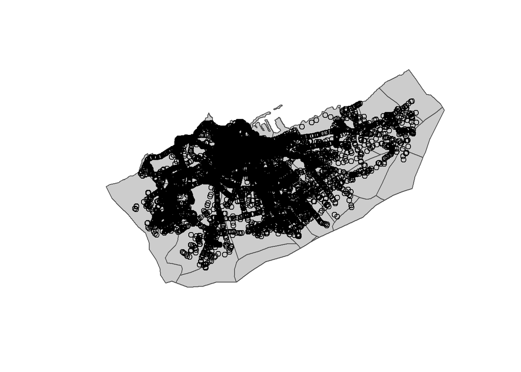

```r
plot(casaNeibProj$geometry, col="grey80", border ="grey30")
plot(heetchM1ProjAtPeakHour$geometry, add=TRUE)
```

## Identifier les zones de concentration à l’heure de pointe

Faire une affihage qui montre le nombre de points par quartiers à l’heure de pointe

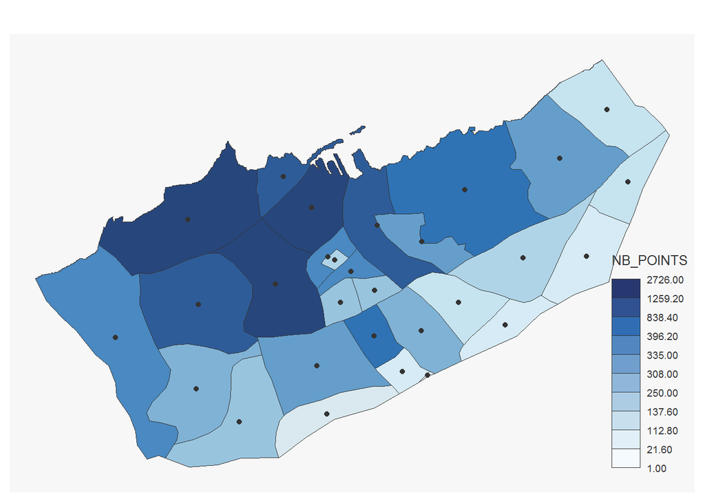

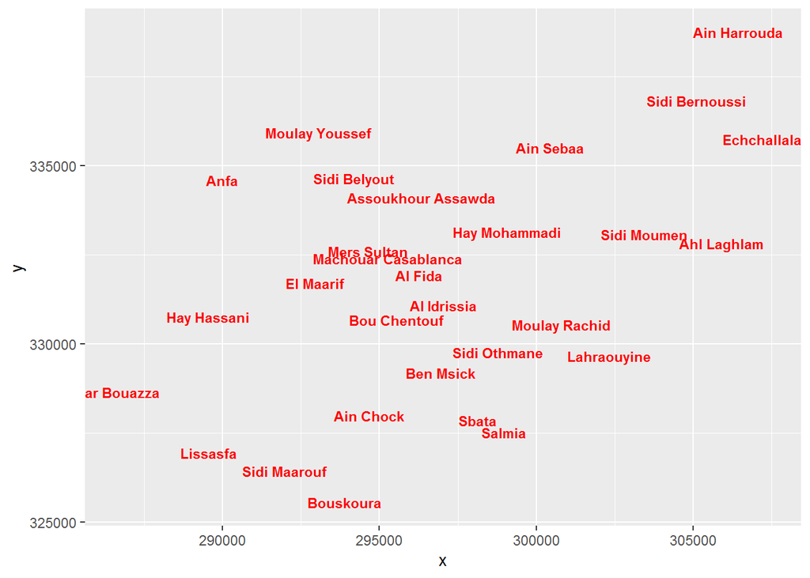

```r
my_fct_ggplot <- function(grid_geometry ){
# create sample data
data <- data.frame(
  Name = polCentroids$NAME_4,
  #Value = c(10, 20, 30),
  geometry = grid_geometry
)

# convert to sf object
sf_data <- st_as_sf(data)

# create the map
ggplot(sf_data) + geom_sf_text(aes(label = Name), size = 3, color = "red", fontface = "bold")
}

my_fct2 <- function(my_points_to_plot, grid_geometry ){
# count the nb the point per cell
# method 1: est-ce que les cellules(carreaux) contiennent les points
#my_points_to_plot <- heetchM1ProjAtPeakHour#polCentroids
inter_grid = st_contains(x = grid_geometry, y=my_points_to_plot) #la grille et les points
inter_grid[72] #le carreau 72 est vide
inter_grid[73] #il va afficher les indexations des points: 882


# create dataframe (cell_id, nb_of_points, geometry_of_the_cell)
list_lengths_per_cell = sapply(X = inter_grid, FUN = length)
casagrid_points = st_sf(ID_GRID = 1:length(list_lengths_per_cell),
                        NB_POINTS = list_lengths_per_cell,
                        geometry = grid_geometry)
class(casagrid_points) #un obj sf et dataf --> cartographiable

# create a carto ---
# beaucoup de carreux en mers (avec nb_points=0) et ça etire la distribution
casagrid_points_crop = casagrid_points %>% filter(NB_POINTS > 0)

#mf_map(x = casaBoundProj,type = "base")
mf_map(x=casagrid_points_crop,
       var = "NB_POINTS",
       type = "choro",
       # 10 classes d'effectifs egaux pour eviter les pb lies aux outiliers
       breaks = "quantile",
       nbreaks = 10,
       pal = rev(hcl.colors(n=10, palette = "Blues")), #un rev pour fnoce rle pire
)
mf_map(x=casaNeibProj, add=TRUE, col="#2596be25", alpha=0.5) #neib
mf_map(x=polCentroids, add = TRUE)
my_fct_ggplot(grid_geometry)
}

my_fct2(heetchM1ProjAtPeakHour, casaNeibProj$geometry)
```

## Résultats

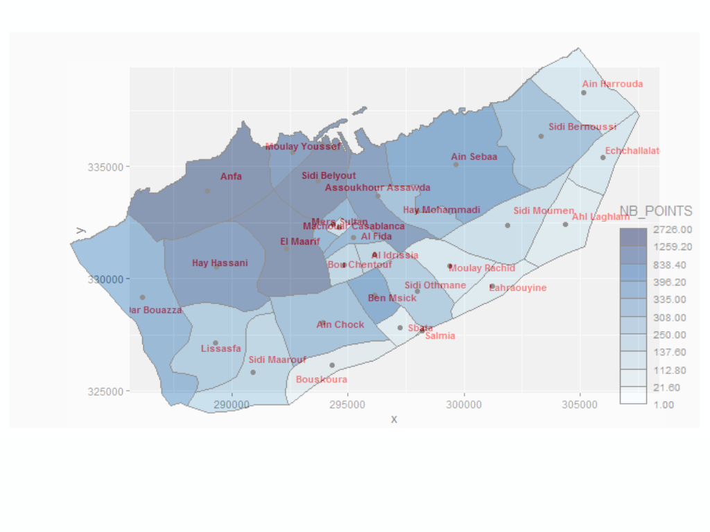

On remarque que les villes `` Anfa``, ``El Maarif`` et `Sidi Belyout `` contiennent les plus grandes concentrations à `22h``